# Practical Machine Learning Course Project

nandini

24/06/2020

# Overview

The aim of this report is to predict how well a person performs an exercise by taking into account various parameters. The dataset taken consists of 6 healthy persons performing 1 set of 10 reps of Dumbbell biceps curl in 5 different fashions.The 5 different fashions include: Class A:exactly according to the specification, Class B:throwing the elbows to the front, Class C:lifting the dumbbell only halfway, Class D:lowering the dumbbell only halfway, Class E:throwing the hips to the front. Class A corressponds to the correct way of performing the exercise while other classes include common mistakes. Here I will be training three Machine learning models to predict the Class and I will be choosing the best model to predict for the test dataset.

```r
pmltrain<-read.csv("pml-training.csv",na.strings = c("NA","","#DIV/0!"))
pmltest<-read.csv("pml-testing.csv",na.strings = c("NA","","#DIV/0!"))
```

# Processing datset

Eliminating columns with more than 60% of NA values. Eliminating unecessary columns. Converting three columns to factors.

```r
dim(pmltrain)
```

```
## [1] 19622   160
```

```r
rno<-which((colSums(!is.na(pmltrain)))>(0.6*nrow(pmltrain)))
rnot<-which((colSums(!is.na(pmltest)))>(0.6*nrow(pmltest)))
pmltrain<-pmltrain[,rno]
pmltest<-pmltest[,rnot]
pmltrain<-pmltrain[,-c(1,5)]
pmltest<-pmltest[,-c(1,5,60)]
pmltrain$user_name=as.factor(pmltrain$user_name)
pmltrain$classe=as.factor(pmltrain$classe)
pmltrain$new_window=as.factor(pmltrain$new_window)
pmltest$user_name=as.factor(pmltest$user_name)
pmltest$new_window=as.factor(pmltest$new_window)
```

```r
set.seed(1231)
inTrain<-createDataPartition(pmltrain$classe,p=.7,list=FALSE)
training<-pmltrain[inTrain,]
testing<-pmltrain[-inTrain,]
dim(training)
```

```
## [1] 13737    58
```

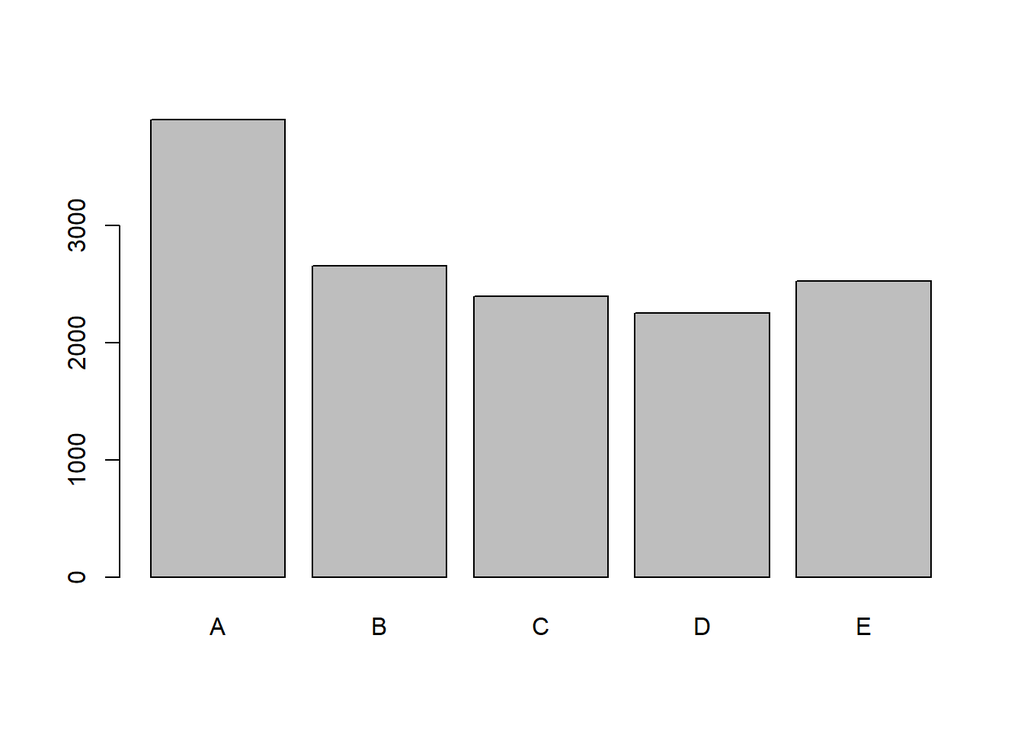

```r
plot(training$classe)
```

# Prediction Models

I will use parallel processing to run these models in order to decrease the computational time.

## 1 Decision Tree

```r
set.seed(1221)
cluster <- makeCluster(detectCores() - 1) # convention to leave 1 core for OS
registerDoParallel(cluster)
fitControl <- trainControl(method = "cv",number = 5,allowParallel = TRUE)
fit0<-train(classe~.,data=training,method="rpart",trControl=fitControl)
cm0<-confusionMatrix(predict(fit0,testing),testing$classe)
cm0
```

```
## Confusion Matrix and Statistics
##
##           Reference
## Prediction    A    B    C    D    E
##          A 1456  292  163  158   32
##          B   48  555   29  177   71
##          C  147  292  834  584  296
##          D    0    0    0    0    0
##          E   23    0    0   45  683
##
## Overall Statistics
##
##                Accuracy : 0.5995
##                  95% CI : (0.5868, 0.612)
##     No Information Rate : 0.2845
##     P-Value [Acc > NIR] : < 2.2e-16
##
##                   Kappa : 0.488
##
##  Mcnemar's Test P-Value : < 2.2e-16
##
## Statistics by Class:
##
##                      Class: A Class: B Class: C Class: D Class: E
## Sensitivity            0.8698  0.48727   0.8129   0.0000   0.6312
## Specificity            0.8468  0.93152   0.7285   1.0000   0.9858
## Pos Pred Value         0.6930  0.63068   0.3874      NaN   0.9095
## Neg Pred Value         0.9424  0.88332   0.9486   0.8362   0.9223
## Prevalence             0.2845  0.19354   0.1743   0.1638   0.1839
## Detection Rate         0.2474  0.09431   0.1417   0.0000   0.1161
## Detection Prevalence   0.3570  0.14953   0.3658   0.0000   0.1276
## Balanced Accuracy      0.8583  0.70940   0.7707   0.5000   0.8085
```

The accuracy for test set=.5995.

Variable Importance:

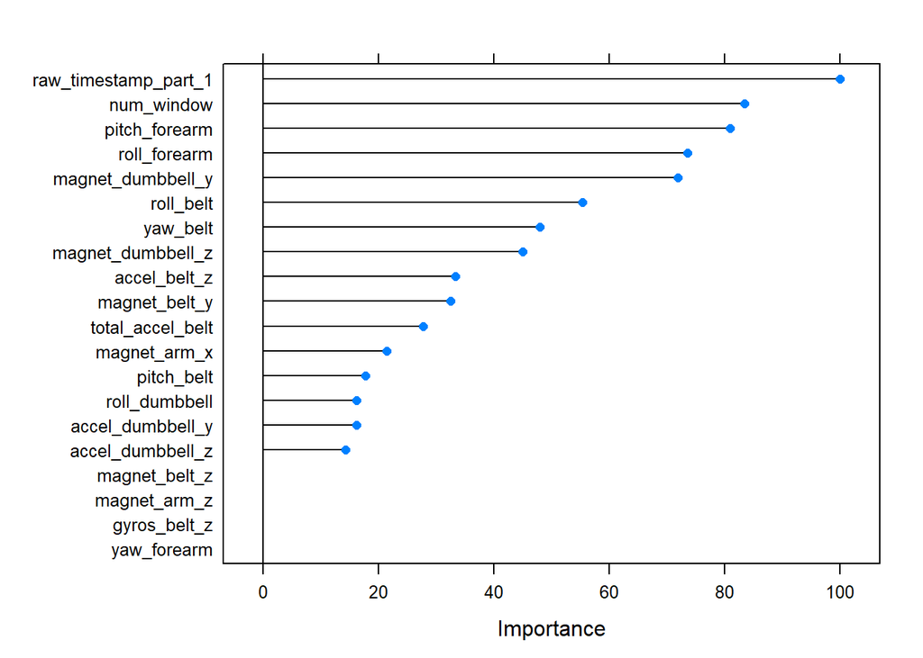

```r
plot(varImp(fit0),top=20)
```

## 2 Random Forest

```r
set.seed(1331)
fit1<-train(classe~.,data=training,method="rf",trControl=fitControl)
cm1<-confusionMatrix(predict(fit1,testing),testing$classe)
cm1
```

```
## Confusion Matrix and Statistics
##
##           Reference
## Prediction    A    B    C    D    E
##          A 1674    3    0    0    0
##          B    0 1135    0    0    0
##          C    0    1 1026    1    0
##          D    0    0    0  963    0
##          E    0    0    0    0 1082
##
## Overall Statistics
##
##                Accuracy : 0.9992
##                  95% CI : (0.998, 0.9997)
##     No Information Rate : 0.2845
##     P-Value [Acc > NIR] : < 2.2e-16
##
##                   Kappa : 0.9989
##
##  Mcnemar's Test P-Value : NA
##
## Statistics by Class:
##
##                      Class: A Class: B Class: C Class: D Class: E
## Sensitivity            1.0000   0.9965   1.0000   0.9990   1.0000
## Specificity            0.9993   1.0000   0.9996   1.0000   1.0000
## Pos Pred Value         0.9982   1.0000   0.9981   1.0000   1.0000
## Neg Pred Value         1.0000   0.9992   1.0000   0.9998   1.0000
## Prevalence             0.2845   0.1935   0.1743   0.1638   0.1839
## Detection Rate         0.2845   0.1929   0.1743   0.1636   0.1839
## Detection Prevalence   0.2850   0.1929   0.1747   0.1636   0.1839
## Balanced Accuracy      0.9996   0.9982   0.9998   0.9995   1.0000
```

The accuracy for test set=.9992,thus low out of sample error.

Variable Importance:

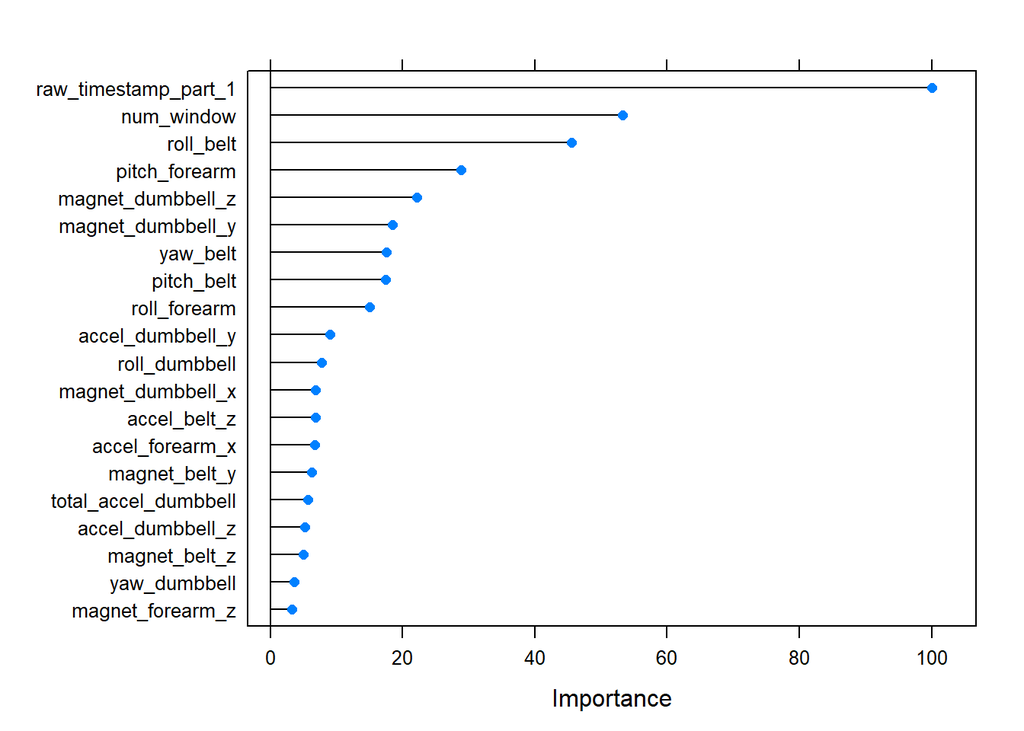

```r
plot(varImp(fit1),top=20)
```

## 3 Linear Discriminant Analysis

```r
set.seed(1441)
fit2<-train(classe~.,data=training,method="lda",trControl=fitControl)
cm2<-confusionMatrix(predict(fit2,testing),testing$classe)
cm2
```

```
## Confusion Matrix and Statistics
##
##           Reference
## Prediction    A    B    C    D    E
##          A 1438  164   96   59   47
##          B   42  764   74   41  133
##          C   88  151  702  109   76
##          D  105   30  133  735   78
##          E    1   30   21   20  748
##
## Overall Statistics
##
##                Accuracy : 0.7455
##                  95% CI : (0.7341, 0.7565)
##     No Information Rate : 0.2845
##     P-Value [Acc > NIR] : < 2.2e-16
##
##                   Kappa : 0.6774
##
##  Mcnemar's Test P-Value : < 2.2e-16
##
## Statistics by Class:
##
##                      Class: A Class: B Class: C Class: D Class: E
## Sensitivity            0.8590   0.6708   0.6842   0.7624   0.6913
## Specificity            0.9131   0.9389   0.9127   0.9297   0.9850
## Pos Pred Value         0.7971   0.7249   0.6234   0.6799   0.9122
## Neg Pred Value         0.9422   0.9224   0.9319   0.9523   0.9341
## Prevalence             0.2845   0.1935   0.1743   0.1638   0.1839
## Detection Rate         0.2444   0.1298   0.1193   0.1249   0.1271
## Detection Prevalence   0.3065   0.1791   0.1913   0.1837   0.1393
## Balanced Accuracy      0.8861   0.8048   0.7985   0.8461   0.8382
```

The accuracy for test set=.7455.

# Comparing Models

```r
result<-resamples(list(DecisionTree=fit0,RandomForest=fit1,LDA=fit2))
summary(result)
```

```
##
## Call:
## summary.resamples(object = result)
##
## Models: DecisionTree, RandomForest, LDA
## Number of resamples: 5
##
## Accuracy
##                   Min.   1st Qu.    Median      Mean   3rd Qu.      Max. NA's
## DecisionTree 0.5920670 0.6155806 0.6246815 0.6230616 0.6265016 0.6564774    0
## RandomForest 0.9967237 0.9981805 0.9992719 0.9986169 0.9992722 0.9996360    0
## LDA          0.7394469 0.7430859 0.7446344 0.7452878 0.7458121 0.7534596    0
##
## Kappa
##                   Min.   1st Qu.    Median      Mean   3rd Qu.      Max. NA's
## DecisionTree 0.4821274 0.5137779 0.5239398 0.5220399 0.5242590 0.5660952    0
## RandomForest 0.9958559 0.9976986 0.9990791 0.9982505 0.9990795 0.9995396    0
## LDA          0.6701454 0.6745685 0.6764199 0.6773827 0.6778141 0.6879658    0
```

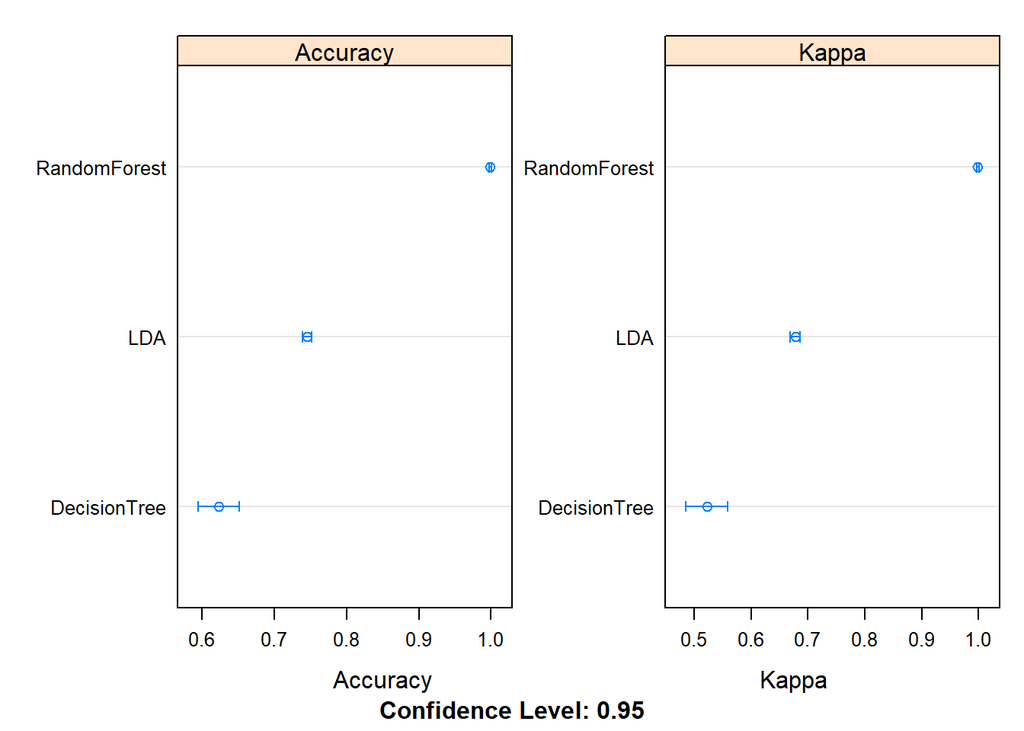

```r
scales<-list(x=list(relation="free"),y=list(relation="free"))
dotplot(result,scales=scales)
```

Random Forest has the highest accuracy and lowest of out of sample error on test set.So I choose Random Forest as the best model for predicting class for this dataset.

# Predicting Test set

```r
predictedclass<-predict(fit1,pmltest)
predictedclass
```

```
##  [1] B A B A A E D B A A B C B A E E A B B B
## Levels: A B C D E
```

```r
stopCluster(cluster)
registerDoSEQ()
```